# posteriorHCA Figure 2 — SAVI manuscript figure (v1)

External population-reference audit of a published STING-activation signature

Author

Affiliation

Chen Zhan

SAiGENCI, The University of Adelaide

Published

09 Aug 2026

Abstract

Fresh v1 manuscript-figure report for the SAVI case (Nature Methods double-column canvas, max 183 mm × 220 mm; no panel titles/subtitles). Panel a freezes the observed cohort design with documented age imputation for GEO non-numeric ages, and regenerates healthy-blood support from the production `V1_monocytic` model frame. Panel b compares observed SAVI composition (CellType → Immune Atlas L3 → paper compartments) to a comprehensive healthy sccomp baseline. Later panels will be added here.

# Scope

**This report (v1).** Build the manuscript multipanel from audited tables. **Panels a–b are in progress** (a complete; b composition plot 1). Helper functions and `theme_multipanel` live in this file.

**Colour / mark grammar.**

| Element | Legend (full) | Plot text (short) | Encoding |
| --- | --- | --- | --- |
| Study healthy control | Control | CTRL | green `#009E73`, circle |
| Pre-therapy SAVI | Untreated SAVI | Untreated | vermilion `#D55E00`, diamond |
| Post–JAK-inhibitor SAVI | JAK-inhibitor treated | Treated | purple `#7A5195`, square |
| Sex | female / male | — | `RColorBrewer` PRGn (`colmap_sex`) |
| Comprehensive HCA | — | — | charcoal grey |
| Metadata-conditioned HCA | — | — | teal |

Figure panels follow Nature Methods style: axis labels and legends only (no plot titles or subtitles); canvas ≤ 183 mm wide × 220 mm high.

# Setup

```r
suppressPackageStartupMessages({
  library(tibble)
  library(dplyr)
  library(tidyr)
  library(stringr)
  library(ggplot2)
  library(patchwork)
  library(targets)
  library(SummarizedExperiment)
  library(scales)
  library(RColorBrewer)
  library(sccomp)
})

options(bitmapType = "cairo")
dir.create(params$fig_dir, recursive = TRUE, showWarnings = FALSE)
dir.create(params$data_dir, recursive = TRUE, showWarnings = FALSE)

model_path <- file.path(
  params$model_store_root,
  paste0("V1_", params$target_cell_type)
)

mm_to_in <- function(mm) mm / 25.4
fig_w_in <- mm_to_in(params$fig_width_mm)
fig_h_in <- mm_to_in(params$fig_height_mm)
panel_a_h_in <- mm_to_in(params$panel_a_height_mm)

# Arcsine–square-root transform for composition proportions (same as posteriorHCA).
arcsine_sqrt_trans <- scales::trans_new(
  "arcsine_sqrt",
  transform = function(x) asin(sqrt(pmax(pmin(x, 1), 0))),
  inverse = function(x) sin(x)^2
)

read_geo_rds_gz <- function(path) {
  con <- gzcon(gzfile(path))
  on.exit(close(con), add = TRUE)
  readRDS(con)
}

# Figure grammar colours.
col_ctrl <- "#009E73"
col_untreated <- "#D55E00"
col_treated <- "#7A5195"
col_hca <- "#8C8C8C"
col_meta <- "#2A9D8F"
col_dark <- "#3F3F3F"
col_mid <- "#777777"
col_light <- "#D9D9D9"

colmap_sex <- setNames(
  RColorBrewer::brewer.pal(3, "PRGn")[c(1, 3)],
  c("female", "male")
)

state_levels <- c("control", "untreated", "treated")
state_labels <- c(
  control = "Control",
  untreated = "Untreated SAVI",
  treated = "JAK-inhibitor treated"
)
state_labels_short <- c(
  control = "CTRL",
  untreated = "Untreated",
  treated = "Treated"
)
state_colours <- c(
  control = col_ctrl,
  untreated = col_untreated,
  treated = col_treated
)
state_shapes <- c(control = 21, untreated = 23, treated = 22)

theme_multipanel <-
  theme_bw() +
  theme(
    panel.border = element_blank(),
    axis.line = element_line(linewidth = 0.1),
    panel.grid.major = element_blank(),
    panel.grid.minor = element_blank(),
    legend.position = "bottom",
    strip.background = element_blank(),
    axis.title.y = element_text(margin = margin(0, 0, 0, 0), size = 7),
    axis.title.x = element_text(margin = margin(0, 0, 0, 0), size = 7),
    panel.spacing.x = unit(0.1, "lines"),
    axis.text.x = element_text(size = 6),
    axis.text.y = element_text(size = 6),
    strip.text.x = element_text(size = 7),
    strip.text.y = element_text(size = 7),
    legend.key.size = unit(4, "mm"),
    legend.title = element_text(size = 7),
    legend.text = element_text(size = 6),
    strip.clip = "off",
    plot.title = element_blank(),
    plot.subtitle = element_blank(),
    plot.tag = element_text(size = 8, face = "bold"),
    axis.line.x = element_line(linewidth = 0.2),
    axis.line.y = element_line(linewidth = 0.2),
    axis.ticks.x = element_line(linewidth = 0.2),
    axis.ticks.y = element_line(linewidth = 0.2),
    plot.margin = margin(2, 4, 2, 2)
  )
```

# Panel a — Observed cohort design and HCA training support

**Purpose.** Show what posteriorHCA can condition on: library ages (including documented imputations), sequencing batches / chemistry, repeated measures, family links, and unique healthy-blood donor age support in the frozen `V1_monocytic` frame.

**Age imputation (same rule as the SAVI case-study reports).** GEO lists non-numeric ages for three libraries. We fill numeric years so every library can sit on the age axis and feed decade-based models:

| Sample(s) | GEO label | Imputed `age_years` | Rationale |
| --- | --- | --- | --- |
| **C1**, **C2** | Adult | **35** | Mean of adult controls with numeric ages (**C8** 36 y, **C9** 35 y). |
| **P5_STING** | Ped | **8** | Central paediatric value among other SAVI / control ages in the series. |

All other donors keep GEO-reported ages. `age_imputed = TRUE` only for C1, C2, and P5.

## Freeze the 17-library source metadata table

Ages, sex and STING batch from GEO GSE226598; subject / family / treatment annotations from de Cevins *et al.* (2023) Fig. 1a. Chemistry: STING1 = 10x 3′ v2; STING2 / STING3 = 10x 3′ v3.

```r
savi_libraries <- tibble::tribble(
  ~library_id,          ~subject_id, ~state,      ~sex,     ~age_years, ~age_imputed, ~sting_batch, ~chemistry,   ~family_role,              ~tx_label,
  "C7",                 "C7",        "control",   "female",         5,        FALSE, "STING1",     "10x 3′ v2",  NA_character_,             NA_character_,
  "C8_aunt_P1_STING",   "C8",        "control",   "female",        36,        FALSE, "STING1",     "10x 3′ v2",  "paternal aunt of P1",     NA_character_,
  "C9_mother_P1_STING", "C9",        "control",   "female",        35,        FALSE, "STING1",     "10x 3′ v2",  "mother of P1",            NA_character_,
  "P1_STING_ht",        "P1",        "untreated", "female",         4,        FALSE, "STING1",     "10x 3′ v2",  "proband",                 NA_character_,
  "P1_STING_ht_T",      "P1",        "treated",   "female",         8,        FALSE, "STING1",     "10x 3′ v2",  "proband",                 "R52",
  "P1_STING_ht_T2",     "P1",        "treated",   "female",         8,        FALSE, "STING1",     "10x 3′ v2",  "proband",                 "T2",
  "P2_STING_ht",        "P2",        "untreated", "male",          31,        FALSE, "STING1",     "10x 3′ v2",  "uncle of P1",             NA_character_,
  "P2_STING_ht_T",      "P2",        "treated",   "male",          34,        FALSE, "STING1",     "10x 3′ v2",  "uncle of P1",             "R1",
  "C10",                "C10",       "control",   "male",          10,        FALSE, "STING2",     "10x 3′ v3",  NA_character_,             NA_character_,
  "C11",                "C11",       "control",   "male",          16,        FALSE, "STING2",     "10x 3′ v3",  NA_character_,             NA_character_,
  "P4_STING_ht",        "P4",        "untreated", "male",           7,        FALSE, "STING2",     "10x 3′ v3",  NA_character_,             NA_character_,
  "P4_STING_ht_T",      "P4",        "treated",   "male",           9,        FALSE, "STING2",     "10x 3′ v3",  NA_character_,             "R13",
  "P6_STING_ht",        "P6",        "untreated", "male",           8,        FALSE, "STING2",     "10x 3′ v3",  NA_character_,             NA_character_,
  "P6_STING_ht_T",      "P6",        "treated",   "male",          10,        FALSE, "STING2",     "10x 3′ v3",  NA_character_,             "R13",
  "C1",                 "C1",        "control",   "male",          35,         TRUE, "STING3",     "10x 3′ v3",  NA_character_,             NA_character_,
  "C2",                 "C2",        "control",   "male",          35,         TRUE, "STING3",     "10x 3′ v3",  NA_character_,             NA_character_,
  "P5_STING",           "P5",        "untreated", "male",           8,         TRUE, "STING3",     "10x 3′ v3",  NA_character_,             NA_character_
) |>
  dplyr::mutate(
    state = factor(state, levels = state_levels),
    sex = factor(sex, levels = c("female", "male")),
    batch_row = factor(
      paste0(sting_batch, " · ", dplyr::recode(chemistry, "10x 3′ v2" = "v2", "10x 3′ v3" = "v3")),
      levels = c("STING1 · v2", "STING2 · v3", "STING3 · v3")
    ),
    display_id = dplyr::case_when(
      subject_id %in% c("C1", "C2") ~ subject_id,
      subject_id == "P5" ~ "P5",
      !is.na(tx_label) ~ tx_label,
      state == "untreated" ~ subject_id,
      TRUE ~ NA_character_
    )
  )

savi_libraries
```

| library_id | subject_id | state | sex | age_years | age_imputed | sting_batch | chemistry | family_role | tx_label | batch_row | display_id |
| --- | --- | --- | --- | --- | --- | --- | --- | --- | --- | --- | --- |
| C7 | C7 | control | female | 5 | FALSE | STING1 | 10x 3′ v2 | NA | NA | STING1 · v2 | NA |
| C8_aunt_P1_STING | C8 | control | female | 36 | FALSE | STING1 | 10x 3′ v2 | paternal aunt of P1 | NA | STING1 · v2 | NA |
| C9_mother_P1_STING | C9 | control | female | 35 | FALSE | STING1 | 10x 3′ v2 | mother of P1 | NA | STING1 · v2 | NA |
| P1_STING_ht | P1 | untreated | female | 4 | FALSE | STING1 | 10x 3′ v2 | proband | NA | STING1 · v2 | P1 |
| P1_STING_ht_T | P1 | treated | female | 8 | FALSE | STING1 | 10x 3′ v2 | proband | R52 | STING1 · v2 | R52 |
| P1_STING_ht_T2 | P1 | treated | female | 8 | FALSE | STING1 | 10x 3′ v2 | proband | T2 | STING1 · v2 | T2 |
| P2_STING_ht | P2 | untreated | male | 31 | FALSE | STING1 | 10x 3′ v2 | uncle of P1 | NA | STING1 · v2 | P2 |
| P2_STING_ht_T | P2 | treated | male | 34 | FALSE | STING1 | 10x 3′ v2 | uncle of P1 | R1 | STING1 · v2 | R1 |
| C10 | C10 | control | male | 10 | FALSE | STING2 | 10x 3′ v3 | NA | NA | STING2 · v3 | NA |
| C11 | C11 | control | male | 16 | FALSE | STING2 | 10x 3′ v3 | NA | NA | STING2 · v3 | NA |

[output cut: 7 more lines]

## Lane offsets and subject connectors

Vertical jitter within a batch row keeps co-located libraries readable. Label offsets are hand-tuned for the STING2 7–10 cluster, the P1 R52/T2 stack, and imputed C1/C2 at age 35.

```r
assign_lanes <- function(df, lane_step = 0.32) {
  df |>
    dplyr::group_by(batch_row, age_years) |>
    dplyr::arrange(state, subject_id, library_id, .by_group = TRUE) |>
    dplyr::mutate(
      lane = (dplyr::row_number() - (dplyr::n() + 1) / 2) * lane_step,
      y_plot = as.numeric(batch_row) + lane
    ) |>
    dplyr::ungroup()
}

label_offset_tbl <- tibble::tribble(
  ~library_id,       ~label_dx, ~label_dy,
  "P1_STING_ht",           0.0,      0.40,
  "P1_STING_ht_T",        -2.0,      0.48,
  "P1_STING_ht_T2",        2.0,     -0.48,
  "P2_STING_ht",           0.0,      0.40,
  "P2_STING_ht_T",         0.0,      0.40,
  "P4_STING_ht",          -0.9,      0.48,
  "P6_STING_ht",          -0.9,     -0.48,
  "P4_STING_ht_T",         0.9,      0.48,
  "P6_STING_ht_T",         0.9,     -0.48,
  "P5_STING",              0.0,      0.40,
  "C1",                   -1.2,      0.40,
  "C2",                    1.2,     -0.40
)

savi_plot <- savi_libraries |>
  assign_lanes() |>
  dplyr::left_join(label_offset_tbl, by = "library_id") |>
  dplyr::mutate(
    label_dx = dplyr::coalesce(label_dx, 0),
    label_dy = dplyr::coalesce(label_dy, 0.40)
  )

savi_connectors <- savi_plot |>
  dplyr::group_by(subject_id) |>
  dplyr::filter(dplyr::n() > 1L) |>
  dplyr::arrange(age_years, state, library_id, .by_group = TRUE) |>
  dplyr::ungroup()
```

## Regenerate frozen `V1_monocytic` healthy-blood support

No-refit audit from the production `pseudobulk_sample` target: healthy blood (`tissue_groups == "blood"`, `disease_groups___altered == "Normal"`), then deduplicate by `donor_id`.

```r
pseudobulk_sample <- targets::tar_read(
  pseudobulk_sample,
  store = file.path(model_path, "_targets")
)

hca_healthy_blood <- SummarizedExperiment::colData(pseudobulk_sample) |>
  as.data.frame() |>
  tibble::as_tibble() |>
  dplyr::filter(
    .data$tissue_groups == "blood",
    as.character(.data$disease_groups___altered) == "Normal"
  ) |>
  dplyr::mutate(
    age_years = as.numeric(.data$age_years),
    sex = as.character(.data$sex),
    assay_groups_altered = as.character(.data$assay_groups___altered),
    dataset_id_altered = as.character(.data$dataset_id___altered)
  )

hca_donors <- hca_healthy_blood |>
  dplyr::group_by(.data$donor_id) |>
  dplyr::summarise(
    sex = dplyr::first(stats::na.omit(.data$sex)),
    age_years = stats::median(.data$age_years, na.rm = TRUE),
    n_samples = dplyr::n(),
    .groups = "drop"
  ) |>
  dplyr::mutate(sex = factor(.data$sex, levels = c("female", "male")))

hca_support_summary <- tibble::tibble(
  n_donors = nrow(hca_donors),
  n_samples = nrow(hca_healthy_blood),
  n_datasets = dplyr::n_distinct(hca_healthy_blood$dataset_id_altered),
  n_assay_groups = dplyr::n_distinct(hca_healthy_blood$assay_groups_altered),
  n_samples_10x3 = sum(
    hca_healthy_blood$assay_groups_altered == "10x Genomics 3",
    na.rm = TRUE
  ),
  age_min = min(hca_donors$age_years, na.rm = TRUE),
  age_max = max(hca_donors$age_years, na.rm = TRUE)
)

overlap_hits <- hca_healthy_blood |>
  dplyr::mutate(
    haystack = paste(
      dplyr::coalesce(as.character(.data$sample_id), ""),
      dplyr::coalesce(as.character(.data$dataset_id), ""),
      dplyr::coalesce(as.character(.data$title), ""),
      dplyr::coalesce(as.character(.data$citation), ""),
      dplyr::coalesce(as.character(.data$url), ""),
      sep = " "
    )
  ) |>
  dplyr::filter(
    stringr::str_detect(
      .data$haystack,
      stringr::regex("GSE226598|GSM70799|de Cevins|SAVI", ignore_case = TRUE)
    )
  )

overlap_status <- if (nrow(overlap_hits) == 0L) {
  "absent (no GSE226598 / SAVI string match)"
} else {
  sprintf("observed (%d rows matched)", nrow(overlap_hits))
}

hca_support_summary
```

| n_donors | n_samples | n_datasets | n_assay_groups | n_samples_10x3 | age_min | age_max |
| --- | --- | --- | --- | --- | --- | --- |
| 569 | 973 | 13 | 4 | 46 | 3.49863 | 89 |

Age support for each SAVI library relative to observed HCA donor ages:

```r
age_support <- range(hca_donors$age_years, na.rm = TRUE)

savi_query_support <- savi_libraries |>
  dplyr::mutate(
    support_flag = dplyr::if_else(
      age_years >= age_support[1] & age_years <= age_support[2],
      "observed",
      "outside support"
    ),
    assay_support = dplyr::if_else(
      hca_support_summary$n_samples_10x3 > 0L,
      "observed (harmonised 10x Genomics 3)",
      "outside support"
    )
  )

savi_query_support |>
  dplyr::count(age_imputed, support_flag, assay_support)
```

| age_imputed | support_flag | assay_support | n |
| --- | --- | --- | --- |
| FALSE | observed | observed (harmonised 10x Genomics 3) | 14 |
| TRUE | observed | observed (harmonised 10x Genomics 3) | 3 |

## Draw panel A

```r
plot_panel_a_collections <- function(plot_df, connector_df) {
  y_labs <- levels(plot_df$batch_row)

  ggplot2::ggplot() +
    ggplot2::geom_hline(
      yintercept = seq_along(y_labs),
      colour = col_light,
      linewidth = 0.25
    ) +
    ggplot2::geom_path(
      data = connector_df,
      ggplot2::aes(x = age_years, y = y_plot, group = subject_id),
      colour = col_mid,
      linewidth = 0.35,
      alpha = 0.85
    ) +
    ggplot2::geom_point(
      data = plot_df,
      ggplot2::aes(
        x = age_years,
        y = y_plot,
        shape = state,
        colour = state,
        fill = sex
      ),
      size = 1.7,
      stroke = 0.45
    ) +
    ggplot2::geom_segment(
      data = plot_df |> dplyr::filter(!is.na(display_id)),
      ggplot2::aes(
        x = age_years,
        xend = age_years + label_dx,
        y = y_plot,
        yend = y_plot + label_dy
      ),
      colour = col_mid,
      linewidth = 0.2,
      alpha = 0.7
    ) +
    ggplot2::geom_text(
      data = plot_df |> dplyr::filter(!is.na(display_id)),
      ggplot2::aes(
        x = age_years + label_dx,
        y = y_plot + label_dy,
        label = display_id
      ),
      size = 2.5,
      colour = col_dark,
      vjust = 0.5,
      hjust = 0.5
    ) +
    ggplot2::scale_shape_manual(
      values = state_shapes,
      labels = state_labels,
      name = NULL,
      guide = ggplot2::guide_legend(order = 1, override.aes = list(fill = "white"))
    ) +
    ggplot2::scale_colour_manual(
      values = state_colours,
      labels = state_labels,
      name = NULL,
      guide = ggplot2::guide_legend(order = 1)
    ) +
    ggplot2::scale_fill_manual(
      values = colmap_sex,
      breaks = c("female", "male"),
      labels = c("female", "male"),
      name = NULL,
      guide = ggplot2::guide_legend(
        order = 2,
        override.aes = list(shape = 21, colour = col_dark)
      )
    ) +
    ggplot2::scale_y_continuous(
      breaks = seq_along(y_labs),
      labels = y_labs,
      limits = c(0.25, length(y_labs) + 0.75)
    ) +
    ggplot2::scale_x_continuous(
      limits = c(0, 40),
      breaks = seq(0, 40, by = 10),
      expand = ggplot2::expansion(mult = c(0.01, 0.02))
    ) +
    ggplot2::coord_cartesian(clip = "off") +
    ggplot2::labs(x = "Age at collection (years)", y = NULL) +
    theme_multipanel +
    ggplot2::theme(
      legend.position = "bottom",
      legend.box = "horizontal",
      legend.margin = margin(0, 0, 0, 0),
      axis.line.y = element_blank(),
      axis.ticks.y = element_blank()
    )
}

plot_panel_a_hca_continuous <- function(donors, savi_marks) {
  brks <- seq(0, 90, by = 10)

  hist_counts <- donors |>
    dplyr::mutate(
      bin_i = pmin(
        findInterval(.data$age_years, brks, all.inside = TRUE),
        length(brks) - 1L
      )
    ) |>
    dplyr::count(bin_i, sex, name = "n") |>
    tidyr::complete(
      bin_i = seq_len(length(brks) - 1L),
      sex = factor(c("female", "male"), levels = c("female", "male")),
      fill = list(n = 0L)
    ) |>
    dplyr::left_join(
      tibble::tibble(
        bin_i = seq_len(length(brks) - 1L),
        xmid = (brks[-length(brks)] + brks[-1]) / 2
      ),
      by = "bin_i"
    ) |>
    dplyr::mutate(sex = factor(sex, levels = c("male", "female")))

  age_marks <- savi_marks |>
    dplyr::distinct(age_years, sex) |>
    dplyr::mutate(sex = factor(sex, levels = c("female", "male")))

  ggplot2::ggplot(hist_counts, ggplot2::aes(x = xmid, y = n, fill = sex)) +
    ggplot2::geom_col(width = 9.2, colour = NA) +
    ggplot2::geom_vline(
      data = age_marks,
      ggplot2::aes(xintercept = age_years, colour = sex),
      linewidth = 0.35,
      alpha = 0.95
    ) +
    ggplot2::scale_fill_manual(
      values = colmap_sex,
      breaks = c("female", "male"),
      labels = c("female", "male"),
      name = NULL
    ) +
    ggplot2::scale_colour_manual(
      values = colmap_sex,
      breaks = c("female", "male"),
      guide = "none"
    ) +
    ggplot2::scale_x_continuous(
      limits = c(0, 90),
      breaks = c(0, 30, 60, 90),
      expand = c(0, 0)
    ) +
    ggplot2::scale_y_continuous(expand = ggplot2::expansion(mult = c(0, 0.08))) +
    ggplot2::labs(x = "Unique donor age (years)", y = NULL) +
    theme_multipanel +
    ggplot2::theme(
      legend.position = "bottom",
      legend.margin = margin(0, 0, 0, 0)
    )
}
```

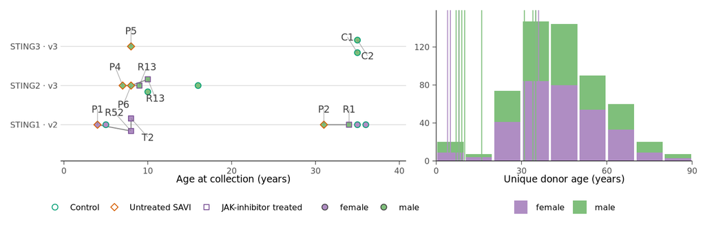

Figure 2a. Observed SAVI collections (left; imputed ages for C1/C2/P5) and frozen V1_monocytic healthy-blood donor-age support (right).

```r
savi_age_marks <- savi_plot |>
  dplyr::distinct(age_years, sex)

p_a_left <- plot_panel_a_collections(savi_plot, savi_connectors)
p_a_right <- plot_panel_a_hca_continuous(hca_donors, savi_age_marks)

panel_a <- (p_a_left | p_a_right) +
  patchwork::plot_layout(widths = c(1.35, 1))

panel_a
```

```r
cat(
  sprintf(
    paste(
      "Panel a: %d libraries / %d subjects (%d age-imputed: C1, C2, P5);",
      "HCA healthy blood = %d donors / %d samples / %d datasets;",
      "%d samples in harmonised `10x Genomics 3`;",
      "donor age range %.1f–%.1f years;",
      "training-overlap status: %s;",
      "SAVI ages in HCA support: %d observed, %d outside.\n"
    ),
    nrow(savi_libraries),
    dplyr::n_distinct(savi_libraries$subject_id),
    sum(savi_libraries$age_imputed),
    hca_support_summary$n_donors,
    hca_support_summary$n_samples,
    hca_support_summary$n_datasets,
    hca_support_summary$n_samples_10x3,
    hca_support_summary$age_min,
    hca_support_summary$age_max,
    overlap_status,
    sum(savi_query_support$support_flag == "observed"),
    sum(savi_query_support$support_flag == "outside support")
  )
)
```

```
Panel a: 17 libraries / 12 subjects (3 age-imputed: C1, C2, P5); HCA healthy blood = 569 donors / 973 samples / 13 datasets; 46 samples in harmonised `10x Genomics 3`; donor age range 3.5–89.0 years; training-overlap status: absent (no GSE226598 / SAVI string match); SAVI ages in HCA support: 17 obs…
```

# Panel b — Composition vs comprehensive healthy baseline

**Purpose.** Recover the paper’s Figure 1E composition story on a shared L3 vocabulary, and place observed cohort proportions against a comprehensive healthy blood baseline from the Immune Atlas sccomp fit.

**Approach.**

1. Map the 23 GEO `CellType` labels and 26 HCA `L3` labels onto the same **15-part** composition (finest defensible shared vocabulary from the Fig. 2 manuscript): seven paper T/NK compartments, seven matched B/myeloid/DC compartments, and `residual`.
2. Fit the 12 independent untreated/control subjects with `sccomp` using `formula_composition = ~ group + sequencing_batch`; treated repeated libraries are excluded from this disease-composition estimand.
3. Standardise both SAVI groups equally over STING1–STING3. Retain a matched `~ group` fit as a no-batch sensitivity, not the primary analysis.
4. Predict comprehensive and personalised healthy nulls from the atlas fit (Normal blood, assay `10x Genomics 3`; other covariates marginalised; personalised fills untreated age×sex only).
5. Display the seven paper compartments in plots b1–b2.

## Harmonise SAVI CellType and HCA L3 → 15 shared compartments

Same finest shared composition as the Fig. 2 manuscript report: seven paper T/NK compartments for display/testing, seven matched B/myeloid/DC compartments kept separate in the likelihood, and `residual` only for unmatched labels.

```r
display_compartments <- c(
  "Naive CD4 T",
  "Eff./memory CD4",
  "Naive CD8 T",
  "Eff./memory CD8",
  "NK",
  "MAIT",
  "gamma-delta T"
)

compartment_levels <- c(
  display_compartments,
  "Naive/transitional B",
  "Memory B",
  "Plasma cells",
  "Classical monocytes",
  "Non-classical monocytes",
  "cDC",
  "pDC",
  "residual"
)

# Alias used by plot helpers / contrasts (paper Figure 1E family).
paper_compartment_levels <- display_compartments

celltype_to_compartment <- tibble::tribble(
  ~cell_type,              ~compartment,
  "0. Naive CD4",          "Naive CD4 T",
  "3. CM CD4",             "Eff./memory CD4",
  "4. EM CD4",             "Eff./memory CD4",
  "8. TE CD4",             "Eff./memory CD4",
  "9. Tregs and TE CD4",   "Eff./memory CD4",
  "2. Naive CD8",          "Naive CD8 T",
  "14. CM CD8",            "Eff./memory CD8",
  "15. EM CD8",            "Eff./memory CD8",
  "7. TE CD8",             "Eff./memory CD8",
  "10. NK",                "NK",
  "26. NK CD56bright",     "NK",
  "22. MAIT",              "MAIT",
  "16. gd T cells",        "gamma-delta T",
  "1. Naive B",            "Naive/transitional B",
  "6. Transitionnal B",    "Naive/transitional B",
  "13. Memory B",          "Memory B",
  "25. Plasmablasts",      "Plasma cells",
  "5. Classical monocytes", "Classical monocytes",
  "12. Non-classical monocytes", "Non-classical monocytes",
  "20. cDCs",              "cDC",
  "27. pDCs",              "pDC",
  "11. CD3+ B cells",      "residual",
  "17. Disease-associated monocytes", "residual"
)

l3_to_compartment <- tibble::tribble(
  ~L3,                ~compartment,
  "b memory",         "Memory B",
  "b naive",          "Naive/transitional B",
  "cd14 mono",        "Classical monocytes",
  "cd16 mono",        "Non-classical monocytes",
  "cdc",              "cDC",
  "pdc",              "pDC",
  "plasma",           "Plasma cells",
  "cd4 naive",        "Naive CD4 T",
  "cd4 tcm",          "Eff./memory CD4",
  "cd4 fh em",        "Eff./memory CD4",
  "cd4 th1 em",       "Eff./memory CD4",
  "cd4 th17 em",      "Eff./memory CD4",
  "cd4 th2 em",       "Eff./memory CD4",
  "cd4 th1/th17 em",  "Eff./memory CD4",
  "treg",             "Eff./memory CD4",
  "cd8 naive",        "Naive CD8 T",
  "cd8 tcm",          "Eff./memory CD8",
  "cd8 tem",          "Eff./memory CD8",
  "nk",               "NK",
  "mait",             "MAIT",
  "tgd",              "gamma-delta T",
  "granulocyte",      "residual",
  "ilc",              "residual",
  "macrophage",       "residual",
  "mast",             "residual",
  "nkt",              "residual"
)

source_direction <- tibble::tibble(
  compartment = factor(display_compartments, levels = display_compartments),
  source_arrow = c("+", "-", "+", "-", "-", "-", "-")
)

stopifnot(nrow(celltype_to_compartment) == 23L)
stopifnot(nrow(l3_to_compartment) == 26L)
stopifnot(!anyDuplicated(celltype_to_compartment$cell_type))
stopifnot(!anyDuplicated(l3_to_compartment$L3))

celltype_to_compartment
```

| cell_type | compartment |
| --- | --- |
| 0. Naive CD4 | Naive CD4 T |
| 3. CM CD4 | Eff./memory CD4 |
| 4. EM CD4 | Eff./memory CD4 |
| 8. TE CD4 | Eff./memory CD4 |
| 9. Tregs and TE CD4 | Eff./memory CD4 |
| 2. Naive CD8 | Naive CD8 T |
| 14. CM CD8 | Eff./memory CD8 |
| 15. EM CD8 | Eff./memory CD8 |
| 7. TE CD8 | Eff./memory CD8 |
| 10. NK | NK |

[output cut: 13 more lines]

```r
l3_to_compartment
```

| L3 | compartment |
| --- | --- |
| b memory | Memory B |
| b naive | Naive/transitional B |
| cd14 mono | Classical monocytes |
| cd16 mono | Non-classical monocytes |
| cdc | cDC |
| pdc | pDC |
| plasma | Plasma cells |
| cd4 naive | Naive CD4 T |
| cd4 tcm | Eff./memory CD4 |
| cd4 fh em | Eff./memory CD4 |

[output cut: 16 more lines]

## SAVI cell-type counts and proportions

```r
if (file.exists(params$panel_b_counts_rds)) {
  panel_b_celltype_counts <- readRDS(params$panel_b_counts_rds)
} else {
  seurat_savi <- read_geo_rds_gz(params$savi_seurat_gz)
  md <- seurat_savi@meta.data
  rm(seurat_savi)
  gc()

  panel_b_celltype_counts <- md |>
    dplyr::transmute(
      sample_id = as.character(.data$Sample),
      Category = as.character(.data$Category),
      cell_type = as.character(.data$CellType)
    ) |>
    dplyr::count(.data$sample_id, .data$Category, .data$cell_type, name = "n_cells")

  saveRDS(panel_b_celltype_counts, params$panel_b_counts_rds, compress = "xz")
}

panel_b_sample_meta <- savi_libraries |>
  dplyr::transmute(
    sample_id = library_id,
    subject_id,
    group = dplyr::recode(
      as.character(state),
      control = "control",
      untreated = "untreated",
      treated = "treated"
    ),
    sequencing_batch = sting_batch,
    sex,
    age_years,
    age_imputed
  ) |>
  dplyr::mutate(
    group = factor(group, levels = c("control", "untreated", "treated")),
    sequencing_batch = factor(
      sequencing_batch,
      levels = c("STING1", "STING2", "STING3")
    )
  )

panel_b_counts_mapped <- panel_b_celltype_counts |>
  dplyr::left_join(celltype_to_compartment, by = "cell_type") |>
  dplyr::inner_join(panel_b_sample_meta, by = "sample_id")

stopifnot(!anyNA(panel_b_counts_mapped$compartment))
stopifnot(setequal(
  unique(panel_b_celltype_counts$cell_type),
  celltype_to_compartment$cell_type
))

sample_totals <- panel_b_celltype_counts |>
  dplyr::group_by(.data$sample_id) |>
  dplyr::summarise(n_total = sum(.data$n_cells), .groups = "drop")

# Observed proportions for the seven paper compartments (plot b1).
panel_b_prop_paper <- panel_b_counts_mapped |>
  dplyr::filter(.data$compartment %in% display_compartments) |>
  dplyr::group_by(.data$sample_id, .data$group, .data$compartment) |>
  dplyr::summarise(n_cells = sum(.data$n_cells), .groups = "drop") |>
  tidyr::complete(
    tidyr::nesting(sample_id, group),
    compartment = display_compartments,
    fill = list(n_cells = 0L)
  ) |>
  dplyr::left_join(sample_totals, by = "sample_id") |>
  dplyr::mutate(
    proportion = .data$n_cells / .data$n_total,
    paper_compartment = factor(.data$compartment, levels = display_compartments),
    state = factor(as.character(.data$group), levels = state_levels)
  )

panel_b_prop_paper |>
  dplyr::group_by(.data$state, .data$paper_compartment) |>
  dplyr::summarise(
    n_samples = dplyr::n(),
    mean_prop = mean(.data$proportion),
    .groups = "drop"
  )
```

| state | paper_compartment | n_samples | mean_prop |
| --- | --- | --- | --- |
| control | Naive CD4 T | 7 | 0.1345421417 |
| control | Eff./memory CD4 | 7 | 0.2731271244 |
| control | Naive CD8 T | 7 | 0.0658225971 |
| control | Eff./memory CD8 | 7 | 0.1310456104 |
| control | NK | 7 | 0.0543124283 |
| control | MAIT | 7 | 0.0174603224 |
| control | gamma-delta T | 7 | 0.0344529284 |
| untreated | Naive CD4 T | 5 | 0.1178313751 |
| untreated | Eff./memory CD4 | 5 | 0.2178529260 |
| untreated | Naive CD8 T | 5 | 0.1517273578 |

[output cut: 11 more lines]

## SAVI sccomp independent-subject fit (`~ group + sequencing_batch`)

The primary fit uses the full **15-part** closed count composition and the 12 independent untreated/control subjects. The batch term prevents a STING-lane difference from being attributed to disease. The matched `~ group` model below is retained only as a formula sensitivity.

```r
panel_b_sccomp_counts <- panel_b_counts_mapped |>
  dplyr::group_by(
    .data$sample_id, .data$subject_id, .data$group,
    .data$sequencing_batch, .data$compartment
  ) |>
  dplyr::summarise(n_cells = sum(.data$n_cells), .groups = "drop") |>
  tidyr::complete(
    tidyr::nesting(sample_id, subject_id, group, sequencing_batch),
    compartment = compartment_levels,
    fill = list(n_cells = 0L)
  ) |>
  dplyr::mutate(
    group = factor(
      as.character(.data$group),
      levels = c("control", "untreated", "treated")
    ),
    sequencing_batch = factor(
      as.character(.data$sequencing_batch),
      levels = c("STING1", "STING2", "STING3")
    ),
    compartment = factor(.data$compartment, levels = compartment_levels)
  )

panel_b_raw_total_check <- panel_b_sccomp_counts |>
  dplyr::group_by(.data$sample_id) |>
  dplyr::summarise(aggregated_n_cells = sum(.data$n_cells), .groups = "drop") |>
  dplyr::left_join(sample_totals, by = "sample_id")

stopifnot(nrow(panel_b_raw_total_check) == 17L)
stopifnot(all(
  panel_b_raw_total_check$aggregated_n_cells == panel_b_raw_total_check$n_total
))

# Panel B2 tests untreated versus control. Repeated treated libraries are not
# independent subjects and do not contribute to this estimand.
panel_b_analysis_counts <- panel_b_sccomp_counts |>
  dplyr::filter(.data$group %in% c("control", "untreated")) |>
  dplyr::mutate(
    group = factor(as.character(.data$group), levels = c("control", "untreated"))
  ) |>
  dplyr::select(
    "sample_id", "subject_id", "group", "sequencing_batch",
    "compartment", "n_cells"
  )

stopifnot(dplyr::n_distinct(panel_b_analysis_counts$sample_id) == 12L)
stopifnot(dplyr::n_distinct(panel_b_analysis_counts$subject_id) == 12L)

panel_b_analysis_counts |>
  dplyr::group_by(.data$sample_id, .data$group) |>
  dplyr::summarise(
    n_cells = sum(.data$n_cells),
    n_compartments = dplyr::n(),
    .groups = "drop"
  )
```

| sample_id | group | n_cells | n_compartments |
| --- | --- | --- | --- |
| C1 | control | 8393 | 15 |
| C10 | control | 7921 | 15 |
| C11 | control | 7163 | 15 |
| C2 | control | 9949 | 15 |
| C7 | control | 5727 | 15 |
| C8_aunt_P1_STING | control | 7139 | 15 |
| C9_mother_P1_STING | control | 7689 | 15 |
| P1_STING_ht | untreated | 9641 | 15 |
| P2_STING_ht | untreated | 4810 | 15 |
| P4_STING_ht | untreated | 6469 | 15 |

[output cut: 2 more lines]

```r
panel_b_savi_fit <- NULL
if (file.exists(params$panel_b_savi_fit_rds) && !isTRUE(params$run_sccomp_panel_b)) {
  panel_b_candidate <- readRDS(params$panel_b_savi_fit_rds)
  panel_b_terms <- attr(
    stats::terms(attr(panel_b_candidate, "formula_composition")),
    "term.labels"
  )
  if (setequal(panel_b_terms, c("group", "sequencing_batch")) &&
      nrow(attr(panel_b_candidate, "model_input")$X) == 12L) {
    panel_b_savi_fit <- panel_b_candidate
  } else {
    message("Ignoring incompatible Panel-B primary sccomp cache.")
  }
}

if (is.null(panel_b_savi_fit)) {
  panel_b_savi_fit <- sccomp::sccomp_estimate(
    panel_b_analysis_counts,
    formula_composition = ~ group + sequencing_batch,
    formula_variability = ~ 1,
    sample = "sample_id",
    cell_group = "compartment",
    abundance = "n_cells",
    cores = min(6L, max(1L, parallel::detectCores() - 2L)),
    inference_method = "hmc",
    verbose = TRUE
  )
  saveRDS(panel_b_savi_fit, params$panel_b_savi_fit_rds, compress = "xz")
}

stopifnot(nrow(attr(panel_b_savi_fit, "model_input")$X) == 12L)
panel_b_savi_fit
```

| compartment | parameter | factor | c_lower | c_effect | c_upper | c_rhat | c_ess_bulk | c_ess_tail | v_upper | v_effect | v_lower | v_rhat | v_ess_bulk | v_ess_tail |
| --- | --- | --- | --- | --- | --- | --- | --- | --- | --- | --- | --- | --- | --- | --- |
| Naive CD4 T | (Intercept) | NA | 1.05039241 | 1.42884497 | 1.779715262 | 1.0013033 | 4778.506 | 2977.184 | -2.901978 | -3.711664 | -4.442820 | 1.000099 | 3471.076 | 2861.023 |
| Naive CD4 T | groupuntreated | group | -0.35632506 | 0.15504749 | 0.633062161 | 1.0000358 | 5830.691 | 3130.659 | NA | NA | NA | NA | NA | NA |
| Naive CD4 T | sequencing_batchSTING2 | sequencing_batch | -0.98482181 | -0.45439649 | 0.072885140 | 0.9993953 | 4905.866 | 3231.632 | NA | NA | NA | NA | NA | NA |
| Naive CD4 T | sequencing_batchSTING3 | sequencing_batch | -0.80542109 | -0.22958406 | 0.295128156 | 1.0009960 | 4323.033 | 3152.607 | NA | NA | NA | NA | NA | NA |
| Eff./memory CD4 | (Intercept) | NA | 1.88458686 | 2.21170215 | 2.512979633 | 0.9999887 | 4779.841 | 3149.814 | -2.150119 | -2.882470 | -3.550695 | 1.000730 | 4363.014 | 3044.727 |
| Eff./memory CD4 | groupuntreated | group | -0.24436567 | 0.18665665 | 0.605622382 | 1.0008504 | 5599.588 | 3379.851 | NA | NA | NA | NA | NA | NA |
| Eff./memory CD4 | sequencing_batchSTING2 | sequencing_batch | -1.28930792 | -0.78571665 | -0.285999933 | 1.0004620 | 5504.439 | 3028.340 | NA | NA | NA | NA | NA | NA |
| Eff./memory CD4 | sequencing_batchSTING3 | sequencing_batch | -0.93949173 | -0.41796621 | 0.059020495 | 1.0007537 | 4848.335 | 3236.488 | NA | NA | NA | NA | NA | NA |
| Naive CD8 T | (Intercept) | NA | 0.38107263 | 0.85704896 | 1.294552936 | 1.0019608 | 3767.537 | 2850.110 | -2.913884 | -3.641115 | -4.288313 | 1.002259 | 4427.865 | 3045.920 |
| Naive CD8 T | groupuntreated | group | 0.39967045 | 0.96438927 | 1.493919711 | 1.0031906 | 4345.202 | 2942.150 | NA | NA | NA | NA | NA | NA |

[output cut: 50 more lines]

### Standardise primary SAVI predictions over sequencing batch

```r
panel_b_savi_newdata <- tidyr::expand_grid(
  group = factor(
    c("control", "untreated"),
    levels = c("control", "untreated")
  ),
  sequencing_batch = factor(
    c("STING1", "STING2", "STING3"),
    levels = c("STING1", "STING2", "STING3")
  )
) |>
  dplyr::mutate(
    sample_id = paste(.data$group, .data$sequencing_batch, sep = "__"),
    target_weight = 1 / 3
  )

# sccomp's posterior-row subsampling uses R's global RNG in addition to the
# generated-quantities seed, so set both for render-to-render reproducibility.
set.seed(20260808L)
panel_b_savi_pred_draws <- sccomp::sccomp_predict(
  panel_b_savi_fit,
  new_data = panel_b_savi_newdata,
  number_of_draws = as.integer(params$panel_b_prediction_draws),
  mcmc_seed = 20260808L,
  summary_instead_of_draws = FALSE
)
```

```
Running standalone generated quantities after 1 MCMC chain, with 1 thread(s) per chain...

Chain 1  Elapsed Time: 0.181 seconds (Generated Quantities)
Chain 1 finished in 0.0 seconds.
```

```r
# Verify closure before response-scale standardisation.
panel_b_savi_prediction_sum_check <- panel_b_savi_pred_draws |>
  dplyr::group_by(.data$.draw, .data$sample_id) |>
  dplyr::summarise(total = sum(.data$proportion), .groups = "drop")

stopifnot(max(abs(panel_b_savi_prediction_sum_check$total - 1)) < 1e-5)

panel_b_savi_group_draws <- panel_b_savi_pred_draws |>
  dplyr::group_by(.data$.draw, .data$group, .data$compartment) |>
  dplyr::summarise(
    proportion = stats::weighted.mean(.data$proportion, .data$target_weight),
    .groups = "drop"
  ) |>
  dplyr::mutate(
    paper_compartment = factor(
      as.character(.data$compartment),
      levels = display_compartments
    ),
    group = factor(as.character(.data$group), levels = c("control", "untreated"))
  )

panel_b_savi_group_sum_check <- panel_b_savi_group_draws |>
  dplyr::group_by(.data$.draw, .data$group) |>
  dplyr::summarise(total = sum(.data$proportion), .groups = "drop")

stopifnot(max(abs(panel_b_savi_group_sum_check$total - 1)) < 1e-5)

panel_b_savi_group_summary <- panel_b_savi_group_draws |>
  dplyr::group_by(.data$group, .data$paper_compartment) |>
  dplyr::summarise(
    median_proportion = stats::median(.data$proportion),
    hpd_lo = stats::quantile(.data$proportion, 0.025),
    hpd_hi = stats::quantile(.data$proportion, 0.975),
    .groups = "drop"
  )

panel_b_savi_group_summary
```

| group | paper_compartment | median_proportion | hpd_lo | hpd_hi |
| --- | --- | --- | --- | --- |
| control | Naive CD4 T | 0.12780601 | 0.0944371140 | 0.169638082 |
| control | Eff./memory CD4 | 0.24394746 | 0.1834026767 | 0.300078339 |
| control | Naive CD8 T | 0.06858836 | 0.0458520965 | 0.099976086 |
| control | Eff./memory CD8 | 0.12879006 | 0.0998639909 | 0.158488222 |
| control | NK | 0.05764597 | 0.0426586675 | 0.077771283 |
| control | MAIT | 0.01689409 | 0.0111474259 | 0.027548014 |
| control | gamma-delta T | 0.03571316 | 0.0256452142 | 0.048413663 |
| control | NA | 0.02997528 | 0.0036478785 | 0.127063975 |
| untreated | Naive CD4 T | 0.11680830 | 0.0780256748 | 0.159647261 |
| untreated | Eff./memory CD4 | 0.22659732 | 0.1661471138 | 0.286972358 |

[output cut: 6 more lines]

### Matched no-batch formula sensitivity

```r
panel_b_group_only_fit <- NULL
if (file.exists(params$panel_b_savi_group_only_fit_rds) &&
    !isTRUE(params$run_sccomp_panel_b)) {
  panel_b_group_only_candidate <- readRDS(params$panel_b_savi_group_only_fit_rds)
  panel_b_group_only_terms <- attr(
    stats::terms(attr(panel_b_group_only_candidate, "formula_composition")),
    "term.labels"
  )
  if (identical(panel_b_group_only_terms, "group") &&
      nrow(attr(panel_b_group_only_candidate, "model_input")$X) == 12L) {
    panel_b_group_only_fit <- panel_b_group_only_candidate
  } else {
    message("Ignoring incompatible Panel-B group-only sensitivity cache.")
  }
}

if (is.null(panel_b_group_only_fit)) {
  panel_b_group_only_fit <- sccomp::sccomp_estimate(
    panel_b_analysis_counts,
    formula_composition = ~ group,
    formula_variability = ~ 1,
    sample = "sample_id",
    cell_group = "compartment",
    abundance = "n_cells",
    cores = min(6L, max(1L, parallel::detectCores() - 2L)),
    inference_method = "hmc",
    verbose = TRUE
  )
  saveRDS(
    panel_b_group_only_fit,
    params$panel_b_savi_group_only_fit_rds,
    compress = "xz"
  )
}

panel_b_group_only_newdata <- tibble::tibble(
  group = factor(
    c("control", "untreated"),
    levels = c("control", "untreated")
  ),
  sample_id = paste0("group_only__", c("control", "untreated"))
)

set.seed(20260811L)
panel_b_group_only_pred <- sccomp::sccomp_predict(
  panel_b_group_only_fit,
  new_data = panel_b_group_only_newdata,
  number_of_draws = as.integer(params$panel_b_prediction_draws),
  mcmc_seed = 20260811L,
  summary_instead_of_draws = FALSE
)
```

```
Running standalone generated quantities after 1 MCMC chain, with 1 thread(s) per chain...

Chain 1  Elapsed Time: 0.071 seconds (Generated Quantities)
Chain 1 finished in 0.0 seconds.
```

```r
panel_b_group_only_draws <- panel_b_group_only_pred |>
  dplyr::mutate(
    group = factor(as.character(.data$group), levels = c("control", "untreated")),
    paper_compartment = factor(
      as.character(.data$compartment),
      levels = display_compartments
    )
  )

panel_b_group_only_sum_check <- panel_b_group_only_draws |>
  dplyr::group_by(.data$.draw, .data$group) |>
  dplyr::summarise(total = sum(.data$proportion), .groups = "drop")

stopifnot(max(abs(panel_b_group_only_sum_check$total - 1)) < 1e-5)
```

## Healthy HCA baselines (`sccomp_predict`)

Both baselines use the same marginalised atlas predict: Normal blood, assay fixed to **`10x Genomics 3`**, ethnicity and dataset left as the sccomp average effect (`NA`).

- **Comprehensive:** sex and age also `NA` (one population null).
- **Personalised:** sex and age set to each untreated SAVI subject, then equal-averaged within each posterior draw.

```r
aggregate_hca_to_paper <- function(predict_tbl) {
  predict_tbl |>
    dplyr::inner_join(l3_to_compartment, by = c("cell_type" = "L3")) |>
    dplyr::group_by(.data$sample_id, .data$compartment, .data$.draw) |>
    dplyr::summarise(proportion = sum(.data$proportion), .groups = "drop")
}

# --- Comprehensive (sex/age marginalised) ---
if (file.exists(params$composition_predict_rds)) {
  predict_res <- readRDS(params$composition_predict_rds)
} else {
  sccomp_est <- readRDS(params$sccomp_estimates_rds)
  set.seed(20260809L)
  predict_res <- sccomp_est |>
    sccomp::sccomp_predict(
      formula_composition = NULL,
      new_data = tibble::tibble(
        assay_groups___altered = "10x Genomics 3",
        disease_groups___altered = "Normal",
        tissue_groups = "blood",
        ethnicity_groups_imputed = NA_character_,
        age_decade = NA_character_,
        sex = NA_character_,
        dataset_id___altered = NA_character_,
        sample_id = "comprehensive_baseline"
      ),
      number_of_draws = as.integer(params$panel_b_prediction_draws),
      mcmc_seed = 20260809L,
      summary_instead_of_draws = FALSE
    ) |>
    dplyr::rename(cell_type = L3) |>
    dplyr::select("sample_id", "cell_type", "proportion", ".draw")
  saveRDS(predict_res, params$composition_predict_rds, compress = "xz")
}

healthy_draws_paper <- aggregate_hca_to_paper(predict_res) |>
  dplyr::filter(.data$compartment %in% display_compartments) |>
  dplyr::transmute(
    .draw,
    paper_compartment = factor(.data$compartment, levels = display_compartments),
    proportion,
    reference_target = "comprehensive_hca"
  )

# --- Personalised (untreated age × sex; other covariates still marginalised) ---
panel_b_personalised_meta <- savi_libraries |>
  dplyr::filter(as.character(.data$state) == "untreated") |>
  dplyr::transmute(
    assay_groups___altered = "10x Genomics 3",
    disease_groups___altered = "Normal",
    tissue_groups = "blood",
    ethnicity_groups_imputed = NA_character_,
    age_decade = as.character(ceiling(.data$age_years / 10)),
    sex = as.character(.data$sex),
    dataset_id___altered = NA_character_,
    sample_id = paste0("personalised_", .data$subject_id),
    target_weight = 1 / dplyr::n()
  )

if (file.exists(params$composition_predict_personalised_rds)) {
  predict_res_personalised <- readRDS(params$composition_predict_personalised_rds)
} else {
  if (!exists("sccomp_est", inherits = FALSE)) {
    sccomp_est <- readRDS(params$sccomp_estimates_rds)
  }
  set.seed(20260811L)
  predict_res_personalised <- sccomp_est |>
    sccomp::sccomp_predict(
      formula_composition = NULL,
      new_data = panel_b_personalised_meta |>
        dplyr::select(-"target_weight"),
      number_of_draws = as.integer(params$panel_b_prediction_draws),
      mcmc_seed = 20260811L,
      summary_instead_of_draws = FALSE
    ) |>
    dplyr::rename(cell_type = L3) |>
    dplyr::select("sample_id", "cell_type", "proportion", ".draw")
  saveRDS(
    predict_res_personalised,
    params$composition_predict_personalised_rds,
    compress = "xz"
  )
}

# Equal-average personalised subjects within each draw on the paper scale.
personalised_draws_paper <- aggregate_hca_to_paper(predict_res_personalised) |>
  dplyr::filter(.data$compartment %in% display_compartments) |>
  dplyr::left_join(
    panel_b_personalised_meta |> dplyr::select("sample_id", "target_weight"),
    by = "sample_id"
  ) |>
  dplyr::group_by(.data$compartment, .data$.draw) |>
  dplyr::summarise(
    proportion = stats::weighted.mean(.data$proportion, .data$target_weight),
    .groups = "drop"
  ) |>
  dplyr::transmute(
    .draw,
    paper_compartment = factor(.data$compartment, levels = display_compartments),
    proportion,
    reference_target = "personalised_hca"
  )

hca_draws_paper <- dplyr::bind_rows(healthy_draws_paper, personalised_draws_paper)

healthy_baseline_paper <- healthy_draws_paper |>
  dplyr::group_by(.data$paper_compartment) |>
  dplyr::summarise(
    median_proportion = stats::median(.data$proportion),
    hpd_lo = stats::quantile(.data$proportion, 0.025),
    hpd_hi = stats::quantile(.data$proportion, 0.975),
    .groups = "drop"
  )

healthy_baseline_paper
```

| paper_compartment | median_proportion | hpd_lo | hpd_hi |
| --- | --- | --- | --- |
| Naive CD4 T | 0.168032845 | 0.095800599 | 0.27329779 |
| Eff./memory CD4 | 0.247735416 | 0.153144995 | 0.39638618 |
| Naive CD8 T | 0.046649940 | 0.023465235 | 0.09511647 |
| Eff./memory CD8 | 0.144688429 | 0.091702434 | 0.24375521 |
| NK | 0.155570980 | 0.073781764 | 0.28527689 |
| MAIT | 0.006599657 | 0.002689984 | 0.01656382 |
| gamma-delta T | 0.012961847 | 0.005906184 | 0.02961839 |

## Plot b1 — Paper compartments vs healthy band

Three cohort boxplots with jitter; grey band = comprehensive healthy 95% interval; dashed line = healthy median. Y-axis uses the arcsine–square-root transform.

```r
summarise_panel_b_pp_test <- function(draws, rope_pp) {
  draws |>
    dplyr::filter(.data$compartment %in% display_compartments) |>
    dplyr::group_by(.data$contrast, .data$compartment) |>
    dplyr::summarise(
      estimate = stats::median(.data$delta_pp),
      .lower = unname(stats::quantile(.data$delta_pp, 0.025)),
      .upper = unname(stats::quantile(.data$delta_pp, 0.975)),
      p_increase = mean(.data$delta_pp > rope_pp),
      p_decrease = mean(.data$delta_pp < -rope_pp),
      .groups = "drop"
    ) |>
    dplyr::mutate(
      pp_pH0 = 1 - pmax(.data$p_increase, .data$p_decrease),
      posterior_direction = dplyr::if_else(
        .data$p_increase >= .data$p_decrease,
        "increase",
        "decrease"
      )
    ) |>
    dplyr::group_by(.data$contrast) |>
    dplyr::arrange(.data$pp_pH0, .by_group = TRUE) |>
    dplyr::mutate(
      pp_FDR = cummean(.data$pp_pH0),
      discovery = .data$pp_FDR <= 0.05
    ) |>
    dplyr::ungroup()
}

plot_panel_b1_composition <- function(obs_df, healthy_df) {
  ggplot2::ggplot(
    obs_df,
    ggplot2::aes(x = state, y = proportion, fill = state)
  ) +
    ggplot2::geom_rect(
      data = healthy_df,
      ggplot2::aes(xmin = -Inf, xmax = Inf, ymin = hpd_lo, ymax = hpd_hi),
      fill = col_hca,
      alpha = 0.25,
      colour = NA,
      inherit.aes = FALSE
    ) +
    ggplot2::geom_hline(
      data = healthy_df,
      ggplot2::aes(yintercept = median_proportion),
      colour = col_dark,
      linewidth = 0.45,
      linetype = "dashed",
      inherit.aes = FALSE
    ) +
    ggplot2::geom_boxplot(
      outlier.shape = NA,
      alpha = 0.75,
      colour = col_dark,
      linewidth = 0.35
    ) +
    ggplot2::geom_jitter(
      ggplot2::aes(colour = state, shape = state),
      width = 0.12,
      size = 1.7,
      stroke = 0.45,
      fill = "white",
      alpha = 0.95
    ) +
    ggplot2::facet_wrap(~paper_compartment, scales = "free_y", ncol = 4) +
    ggplot2::scale_fill_manual(
      values = state_colours,
      labels = state_labels,
      name = NULL
    ) +
    ggplot2::scale_colour_manual(
      values = state_colours,
      labels = state_labels,
      name = NULL
    ) +
    ggplot2::scale_shape_manual(
      values = state_shapes,
      labels = state_labels,
      name = NULL
    ) +
    ggplot2::scale_x_discrete(labels = state_labels_short) +
    ggplot2::scale_y_continuous(
      trans = arcsine_sqrt_trans,
      labels = scales::label_number(accuracy = 0.01)
    ) +
    ggplot2::labs(x = NULL, y = "Proportion (arcsin√ scale)") +
    theme_multipanel +
    ggplot2::theme(legend.position = "bottom")
}

plot_panel_b2_effects <- function(effects_df) {
  y_labels <- effects_df |>
    dplyr::distinct(.data$compartment, .data$source_arrow) |>
    dplyr::mutate(
      y_lab = paste(.data$source_arrow, as.character(.data$compartment))
    ) |>
    dplyr::arrange(.data$compartment)

  lab_map <- setNames(y_labels$y_lab, as.character(y_labels$compartment))

  contrast_breaks <- c(
    "untreated - study control",
    "untreated - comprehensive HCA",
    "untreated - personalised HCA"
  )
  contrast_labels <- c(
    "vs study control",
    "vs comprehensive HCA",
    "vs personalised HCA"
  )
  contrast_colours <- c(
    "untreated - study control" = col_ctrl,
    "untreated - comprehensive HCA" = col_hca,
    "untreated - personalised HCA" = col_meta
  )
  contrast_fills <- c(
    "untreated - study control" = "white",
    "untreated - comprehensive HCA" = col_hca,
    "untreated - personalised HCA" = col_meta
  )
  contrast_shapes <- c(
    "untreated - study control" = 21,
    "untreated - comprehensive HCA" = 23,
    "untreated - personalised HCA" = 24
  )
  # Tight dodge so the three series sit on one compartment row.
  contrast_dodge <- ggplot2::position_dodge(width = 0.55)

  ggplot2::ggplot(
    effects_df,
    ggplot2::aes(
      y = .data$compartment,
      x = .data$estimate,
      colour = .data$contrast,
      fill = .data$contrast,
      shape = .data$contrast,
      group = .data$contrast
    )
  ) +
    ggplot2::geom_vline(
      xintercept = 0,
      colour = col_mid,
      linetype = "22",
      linewidth = 0.35
    ) +
    ggplot2::geom_linerange(
      ggplot2::aes(xmin = .data$.lower, xmax = .data$.upper),
      linewidth = 0.55,
      position = contrast_dodge
    ) +
    ggplot2::geom_point(
      ggplot2::aes(size = .data$discovery),
      stroke = 0.6,
      position = contrast_dodge
    ) +
    ggplot2::scale_colour_manual(
      values = contrast_colours,
      breaks = contrast_breaks,
      labels = contrast_labels,
      name = NULL
    ) +
    ggplot2::scale_fill_manual(
      values = contrast_fills,
      breaks = contrast_breaks,
      labels = contrast_labels,
      name = NULL
    ) +
    ggplot2::scale_shape_manual(
      values = contrast_shapes,
      breaks = contrast_breaks,
      labels = contrast_labels,
      name = NULL
    ) +
    ggplot2::scale_size_manual(
      values = c(`FALSE` = 2.0, `TRUE` = 2.8),
      guide = "none"
    ) +
    ggplot2::scale_y_discrete(
      limits = rev(display_compartments),
      labels = lab_map
    ) +
    ggplot2::scale_x_continuous(breaks = c(-20, -10, 0, 10, 20)) +
    ggplot2::coord_cartesian(xlim = c(-22, 22), clip = "off") +
    ggplot2::labs(
      x = "Composition difference (percentage points)",
      y = NULL
    ) +
    theme_multipanel +
    ggplot2::theme(
      legend.position = "bottom",
      legend.direction = "horizontal",
      legend.box = "horizontal",
      legend.margin = margin(2, 0, 0, 0),
      legend.spacing.x = grid::unit(2, "mm"),
      plot.margin = margin(4, 8, 2, 2)
    ) +
    ggplot2::guides(
      colour = ggplot2::guide_legend(override.aes = list(size = 2.4)),
      fill = ggplot2::guide_legend(override.aes = list(size = 2.4)),
      shape = ggplot2::guide_legend(override.aes = list(size = 2.4))
    )
}
```

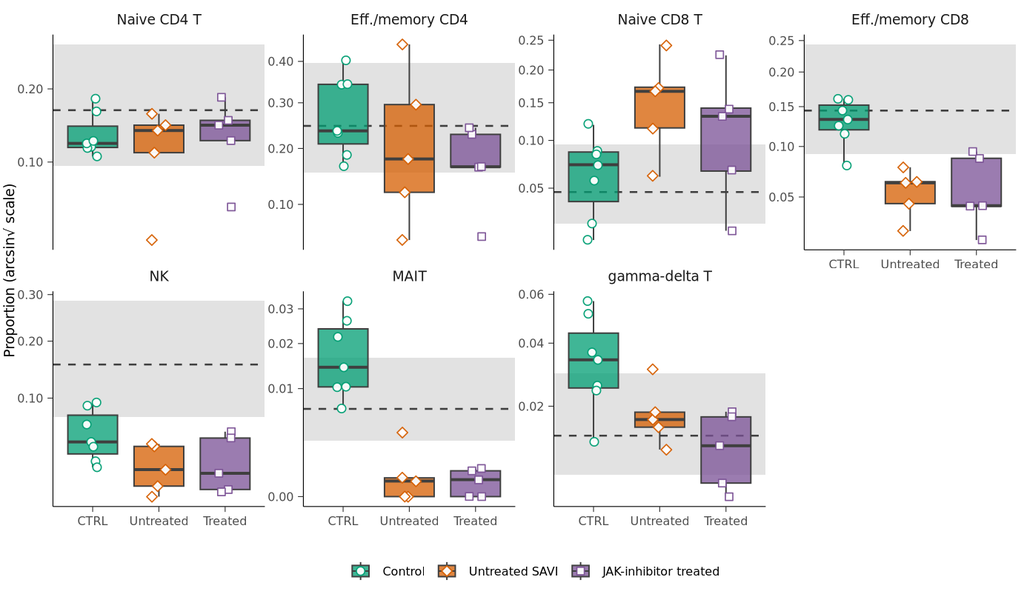

Figure 2b1. Observed SAVI paper-compartment proportions by cohort versus the comprehensive healthy sccomp baseline. Grey band = healthy 95% interval; dashed line = healthy median. Y-axis arcsine–square-root transformed.

```r
panel_b1 <- plot_panel_b1_composition(panel_b_prop_paper, healthy_baseline_paper)
panel_b1
```

## Plot b2 — Composition differences

Forest plot: untreated SAVI versus study controls, comprehensive HCA, and personalised HCA (untreated age×sex; assay / ethnicity / dataset still marginalised as in the comprehensive null). Contrasts are percentage-point differences with a 1-pp ROPE and Bayesian FDR across the seven paper compartments.

```r
# Untreated − control (same SAVI posterior draws).
panel_b_uc_draws <- panel_b_savi_group_draws |>
  dplyr::filter(.data$compartment %in% display_compartments) |>
  dplyr::select(".draw", "group", compartment = "paper_compartment", "proportion") |>
  tidyr::pivot_wider(names_from = "group", values_from = "proportion") |>
  dplyr::mutate(
    delta_pp = 100 * (.data$untreated - .data$control),
    contrast = "untreated - study control"
  ) |>
  dplyr::select(".draw", "compartment", "delta_pp", "contrast")

panel_b_uc <- summarise_panel_b_pp_test(
  panel_b_uc_draws,
  rope_pp = params$panel_b_rope_pp
)

# Untreated − HCA references (independent cross-model pairs).
untreated_draws <- panel_b_savi_group_draws |>
  dplyr::filter(
    .data$group == "untreated",
    .data$compartment %in% display_compartments
  ) |>
  dplyr::transmute(
    .draw = .data$.draw,
    compartment = .data$paper_compartment,
    case_proportion = .data$proportion
  )

set.seed(20260810L)
panel_b_cross_fit_pairs <- tibble::tibble(
  .pair = seq_len(as.integer(params$panel_b_pair_draws)),
  .draw_savi = sample(
    unique(untreated_draws$.draw),
    as.integer(params$panel_b_pair_draws),
    replace = TRUE
  ),
  .draw_hca = sample(
    unique(healthy_draws_paper$.draw),
    as.integer(params$panel_b_pair_draws),
    replace = TRUE
  )
)

panel_b_uh_draws <- panel_b_cross_fit_pairs |>
  dplyr::left_join(
    untreated_draws,
    by = c(".draw_savi" = ".draw"),
    relationship = "many-to-many"
  ) |>
  dplyr::left_join(
    hca_draws_paper |>
      dplyr::transmute(
        .draw,
        compartment = .data$paper_compartment,
        hca_proportion = .data$proportion,
        reference_target
      ),
    by = c(".draw_hca" = ".draw", "compartment"),
    relationship = "many-to-many"
  ) |>
  dplyr::mutate(
    delta_pp = 100 * (.data$case_proportion - .data$hca_proportion),
    contrast = dplyr::recode(
      .data$reference_target,
      comprehensive_hca = "untreated - comprehensive HCA",
      personalised_hca = "untreated - personalised HCA"
    )
  )

panel_b_uh <- summarise_panel_b_pp_test(
  panel_b_uh_draws,
  rope_pp = params$panel_b_rope_pp
)

panel_b2_effects <- dplyr::bind_rows(panel_b_uc, panel_b_uh) |>
  dplyr::mutate(
    compartment = factor(
      as.character(.data$compartment),
      levels = display_compartments
    ),
    contrast = factor(
      .data$contrast,
      levels = c(
        "untreated - study control",
        "untreated - comprehensive HCA",
        "untreated - personalised HCA"
      )
    )
  ) |>
  dplyr::left_join(source_direction, by = "compartment")

panel_b2_effects |>
  dplyr::arrange(.data$compartment, .data$contrast)
```

| contrast | compartment | estimate | .lower | .upper | p_increase | p_decrease | pp_pH0 | posterior_direction | pp_FDR | discovery | source_arrow |
| --- | --- | --- | --- | --- | --- | --- | --- | --- | --- | --- | --- |
| untreated - study control | Naive CD4 T | -1.3280337 | -7.096494 | 4.3703092 | 0.189189189 | 0.557057057 | 0.442942943 | decrease | 0.1263763764 | FALSE | + |
| untreated - comprehensive HCA | Naive CD4 T | -5.2036342 | -16.645040 | 3.3670957 | 0.084350000 | 0.821250000 | 0.178750000 | decrease | 0.0487500000 | TRUE | + |
| untreated - personalised HCA | Naive CD4 T | -10.7550958 | -15.807479 | -5.4706822 | 0.000000000 | 0.999750000 | 0.000250000 | decrease | 0.0001250000 | TRUE | + |
| untreated - study control | Eff./memory CD4 | -1.5578007 | -9.691781 | 6.6743255 | 0.261261261 | 0.549549550 | 0.450450450 | decrease | 0.1726726727 | FALSE | - |
| untreated - comprehensive HCA | Eff./memory CD4 | -2.2703513 | -17.304939 | 9.3394829 | 0.314450000 | 0.574100000 | 0.425900000 | decrease | 0.1241800000 | FALSE | - |
| untreated - personalised HCA | Eff./memory CD4 | 5.2174559 | -1.097279 | 11.5589653 | 0.898950000 | 0.026950000 | 0.101050000 | increase | 0.0206700000 | TRUE | - |
| untreated - study control | Naive CD8 T | 6.7425640 | 1.578732 | 12.6367698 | 0.981981982 | 0.003003003 | 0.018018018 | increase | 0.0125125125 | TRUE | + |
| untreated - comprehensive HCA | Naive CD8 T | 8.8994771 | 2.624675 | 14.8748318 | 0.990900000 | 0.003800000 | 0.009100000 | increase | 0.0054166667 | TRUE | + |
| untreated - personalised HCA | Naive CD8 T | 7.8053397 | 3.527037 | 13.2619480 | 0.998500000 | 0.000000000 | 0.001500000 | increase | 0.0005750000 | TRUE | + |
| untreated - study control | Eff./memory CD8 | -6.6123862 | -10.351549 | -2.5694770 | 0.001501502 | 0.992492492 | 0.007507508 | decrease | 0.0075075075 | TRUE | - |

[output cut: 11 more lines]

### Formula sensitivity: remove sequencing batch

This sensitivity uses the same 12 subjects, 15-part harmonisation, HCA draws, ROPE and draw-pairing rule. Consequently, any difference below is attributable to the SAVI composition formula rather than to a changed sample set or atlas reference.

```r
panel_b_group_only_uc_draws <- panel_b_group_only_draws |>
  dplyr::filter(.data$compartment %in% display_compartments) |>
  dplyr::select(".draw", "group", "compartment", "proportion") |>
  tidyr::pivot_wider(names_from = "group", values_from = "proportion") |>
  dplyr::mutate(
    delta_pp = 100 * (.data$untreated - .data$control),
    contrast = "untreated - study control"
  ) |>
  dplyr::select(".draw", "compartment", "delta_pp", "contrast")

panel_b_group_only_uc <- summarise_panel_b_pp_test(
  panel_b_group_only_uc_draws,
  rope_pp = params$panel_b_rope_pp
)

panel_b_group_only_untreated <- panel_b_group_only_draws |>
  dplyr::filter(
    .data$group == "untreated",
    .data$compartment %in% display_compartments
  ) |>
  dplyr::transmute(
    .draw = .data$.draw,
    compartment = .data$compartment,
    case_proportion = .data$proportion
  )

set.seed(20260812L)
panel_b_group_only_pairs <- tibble::tibble(
  .pair = seq_len(as.integer(params$panel_b_pair_draws)),
  .draw_savi = sample(
    unique(panel_b_group_only_untreated$.draw),
    as.integer(params$panel_b_pair_draws),
    replace = TRUE
  ),
  .draw_hca = sample(
    unique(healthy_draws_paper$.draw),
    as.integer(params$panel_b_pair_draws),
    replace = TRUE
  )
)

panel_b_group_only_uh_draws <- panel_b_group_only_pairs |>
  dplyr::left_join(
    panel_b_group_only_untreated,
    by = c(".draw_savi" = ".draw"),
    relationship = "many-to-many"
  ) |>
  dplyr::left_join(
    healthy_draws_paper |>
      dplyr::transmute(
        .draw = .data$.draw,
        compartment = as.character(.data$paper_compartment),
        hca_proportion = .data$proportion
      ),
    by = c(".draw_hca" = ".draw", "compartment"),
    relationship = "many-to-many"
  ) |>
  dplyr::mutate(
    delta_pp = 100 * (.data$case_proportion - .data$hca_proportion),
    contrast = "untreated - comprehensive HCA"
  )

panel_b_group_only_uh <- summarise_panel_b_pp_test(
  panel_b_group_only_uh_draws,
  rope_pp = params$panel_b_rope_pp
)

panel_b_formula_sensitivity <- dplyr::bind_rows(
  panel_b2_effects |>
    dplyr::filter(.data$contrast %in% c(
      "untreated - study control",
      "untreated - comprehensive HCA"
    )) |>
    dplyr::transmute(
      contrast = as.character(.data$contrast),
      compartment = as.character(.data$compartment),
      model = "primary",
      estimate,
      discovery
    ),
  dplyr::bind_rows(panel_b_group_only_uc, panel_b_group_only_uh) |>
    dplyr::transmute(
      contrast = as.character(.data$contrast),
      compartment = as.character(.data$compartment),
      model = "no_batch",
      estimate,
      discovery
    )
) |>
  tidyr::pivot_wider(
    names_from = "model",
    values_from = c("estimate", "discovery")
  ) |>
  dplyr::mutate(
    estimate_shift_pp = .data$estimate_no_batch - .data$estimate_primary,
    direction_changed = sign(.data$estimate_primary) != sign(.data$estimate_no_batch),
    discovery_changed = .data$discovery_primary != .data$discovery_no_batch
  ) |>
  dplyr::arrange(.data$contrast, match(.data$compartment, display_compartments))

panel_b_formula_sensitivity |>
  dplyr::select(
    contrast,
    compartment,
    primary_pp = .data$estimate_primary,
    no_batch_pp = .data$estimate_no_batch,
    estimate_shift_pp,
    direction_changed,
    discovery_changed
  ) |>
  knitr::kable(
    digits = 2,
    caption = paste(
      "Sequencing-batch formula sensitivity using an identical 12-subject",
      "analysis set and HCA reference."
    )
  )
```

Sequencing-batch formula sensitivity using an identical 12-subject analysis set and HCA reference.

| contrast | compartment | primary_pp | no_batch_pp | estimate_shift_pp | direction_changed | discovery_changed |
| --- | --- | --- | --- | --- | --- | --- |
| untreated - comprehensive HCA | Naive CD4 T | -5.20 | -5.35 | -0.14 | FALSE | FALSE |
| untreated - comprehensive HCA | Eff./memory CD4 | -2.27 | -2.63 | -0.36 | FALSE | FALSE |
| untreated - comprehensive HCA | Naive CD8 T | 8.90 | 10.28 | 1.38 | FALSE | FALSE |
| untreated - comprehensive HCA | Eff./memory CD8 | -8.31 | -8.49 | -0.18 | FALSE | FALSE |
| untreated - comprehensive HCA | NK | -13.21 | -12.88 | 0.33 | FALSE | FALSE |
| untreated - comprehensive HCA | MAIT | -0.47 | -0.42 | 0.04 | FALSE | FALSE |
| untreated - comprehensive HCA | gamma-delta T | 0.72 | 0.75 | 0.03 | FALSE | FALSE |
| untreated - study control | Naive CD4 T | -1.33 | -1.76 | -0.43 | FALSE | FALSE |
| untreated - study control | Eff./memory CD4 | -1.56 | -2.66 | -1.10 | FALSE | FALSE |
| untreated - study control | Naive CD8 T | 6.74 | 8.28 | 1.54 | FALSE | FALSE |
| untreated - study control | Eff./memory CD8 | -6.61 | -6.41 | 0.20 | FALSE | FALSE |
| untreated - study control | NK | -3.37 | -2.59 | 0.79 | FALSE | FALSE |
| untreated - study control | MAIT | -1.49 | -1.50 | -0.01 | FALSE | FALSE |
| untreated - study control | gamma-delta T | -1.49 | -1.24 | 0.24 | FALSE | FALSE |

```r
panel_b_formula_max_shift <- panel_b_formula_sensitivity |>
  dplyr::slice_max(abs(.data$estimate_shift_pp), n = 1, with_ties = FALSE)

panel_b_formula_discovery_changes <- panel_b_formula_sensitivity |>
  dplyr::filter(.data$discovery_changed)

cat(sprintf(
  paste0(
    "**Formula-sensitivity conclusion.** Removing sequencing batch changed no ",
    "effect direction, but shifted the largest posterior median by %.2f percentage ",
    "points (%s; %s) and changed %d discovery decision%s. Therefore the ",
    "batch-adjusted model remains primary.\n\n"
  ),
  abs(panel_b_formula_max_shift$estimate_shift_pp),
  panel_b_formula_max_shift$compartment,
  panel_b_formula_max_shift$contrast,
  nrow(panel_b_formula_discovery_changes),
  ifelse(nrow(panel_b_formula_discovery_changes) == 1L, "", "s")
))
```

**Formula-sensitivity conclusion.** Removing sequencing batch changed no effect direction, but shifted the largest posterior median by 1.54 percentage points (Naive CD8 T; untreated - study control) and changed 0 discovery decisions. Therefore the batch-adjusted model remains primary.

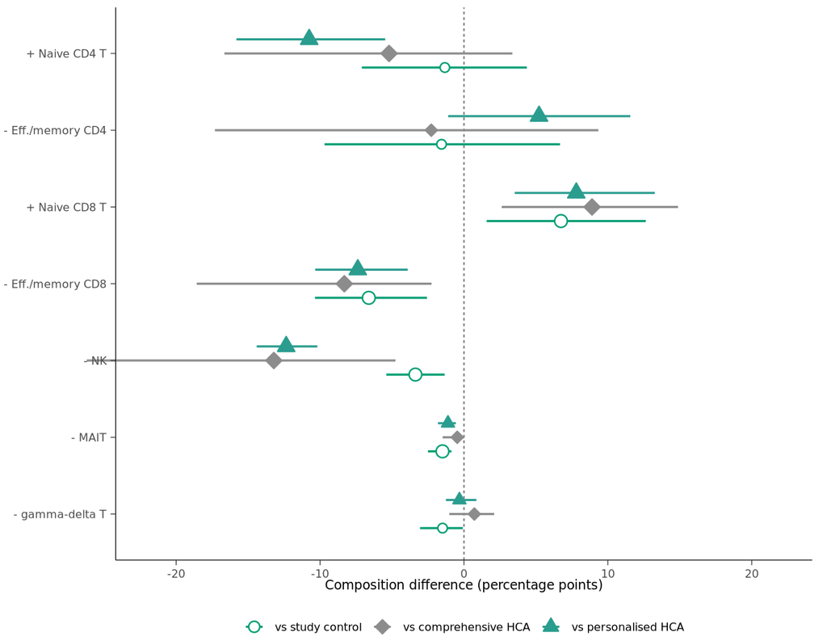

Figure 2b2. Posterior mean-composition differences. Green open circles: untreated − study control. Grey diamonds: untreated − comprehensive HCA. Teal triangles: untreated − personalised HCA. Larger symbols meet Bayesian FDR ≤ 0.05 for a 1-percentage-point ROPE.

```r
panel_b2 <- plot_panel_b2_effects(panel_b2_effects)
panel_b2
```

```r
cat(
  sprintf(
    paste(
      "Panel b: %d observed libraries; primary sccomp uses %d independent",
      "untreated/control subjects with ~ group + sequencing_batch on %d shared compartments;",
      "%d paper compartments shown;",
      "HCA baselines = comprehensive + personalised (%d L3 types × %d draws);",
      "b2 contrasts use %.2f-pp ROPE and %d cross-model pairs.\n"
    ),
    dplyr::n_distinct(panel_b_prop_paper$sample_id),
    dplyr::n_distinct(panel_b_analysis_counts$subject_id),
    length(compartment_levels),
    length(display_compartments),
    dplyr::n_distinct(predict_res$cell_type),
    dplyr::n_distinct(predict_res$.draw),
    params$panel_b_rope_pp,
    nrow(panel_b_cross_fit_pairs)
  )
)
```

```
Panel b: 17 observed libraries; primary sccomp uses 12 independent untreated/control subjects with ~ group + sequencing_batch on 15 shared compartments; 7 paper compartments shown; HCA baselines = comprehensive + personalised (26 L3 types × 500 draws); b2 contrasts use 1.00-pp ROPE and 20000 cross-m…
```

# Next panels

Panels c–f will be added in this v1 report as their analyses land.